# 2019202265-贾耀博-第十一周作业

# 4.1

**对A，B，C三个灯泡生产的灯泡进行寿命测试，每个品牌随机试验不等量的灯泡。结果得到如下寿命数据，试比较三个品牌灯泡寿命是否相同**

```r
lamp<-c(83,64,67,62,70,85,81,80,78,88,89,79,90,95)
gr.lamp<-c(rep(1,5),rep(2,4),rep(3,5))
kruskal.test(lamp, gr.lamp)
```

```
##
##  Kruskal-Wallis rank sum test
##
## data:  lamp and gr.lamp
## Kruskal-Wallis chi-squared = 7.8229, df = 2, p-value = 0.02001
```

根据Kruskal-Wallis检验，p值为0.02001<0.05,从而拒绝原假设，认为三组灯泡寿命不同

# 4.2

**在R中编写程序，完成例4.7中的Dunn检验**

```r
library(tidyverse)

SE<-function(n_i,n_j){
  mst<-(25)*(25+1)/12
  return (sqrt(mst*(1/n_i+1/n_j)))
}

Dij<-function (x,y, mean_rank_x, mean_rank_y){
  se<-SE(length(x), length(y))
  return (abs(mean_rank_x-mean_rank_y)/se)
}

A <- c(80,203,236,252,284,368,457,393)
B <- c(133,180,100,160)
C <- c(156,295,320,448,465,481,279)
D <- c(194,214,272,330,386,475)
A.mean_rank <- 13
B.mean_rank <- 4
C.mean_rank <- 16.7
D.mean_rank <- 14.7
z<-2.638

# A vs B
AB<- c("A VS B",SE(length(A), length(B)),Dij(A,B, A.mean_rank, B.mean_rank))
# A vs C
AC<- c("A VS C",SE(length(A), length(C)),Dij(A,C, A.mean_rank, C.mean_rank))
# A vs D
AD<- c("A VS D",SE(length(A), length(D)),Dij(A,D, A.mean_rank, D.mean_rank))
# B vs C
BC<- c("B VS C",SE(length(B), length(C)),Dij(B,C, B.mean_rank, C.mean_rank))
# B vs D
BD<- c("B VS D",SE(length(B), length(D)),Dij(B,D, B.mean_rank, D.mean_rank))
# C vs D
CD<- c("C VS D",SE(length(C), length(D)),Dij(C,D, C.mean_rank, D.mean_rank))

dt.drug<-rbind(AB,AC,AD,BC,BD,CD)
dt.drug<-as.data.frame(dt.drug,col.names=c("Comparison","SE","dij"))

print(dt.drug)
```

```
##        V1               V2                V3
## AB A VS B 4.50693909432999  1.99692070641082
## AC A VS C 3.80905875137528 0.971368582504562
## AD A VS D 3.97474667257061 0.427700213382543
## BC B VS C  4.6129992309518  2.75308955500944
## BD B VS D 4.75073093791308  2.25228499358045
## CD C VS D 4.09461512426663 0.488446395888848
```

由上表所示四种药物疗效比较结果可知，仅B与C有显著性差异，其他疗效都不存在显著性差异

# 4.3

**假设有10个独立假设检验，得到如下有顺序的p值，在$\alpah=0.05$ 的显著性水平下，计算Benferroni检验和BH检验拒绝原假设的个数**

```r
pvalues<-c(0.00017,0.00448,0.00671,0.00907,0.01220,0.33626,0.39341,0.53882,0.58125,0.98617)

alpha <- 0.05

m<-length(pvalues)

# Benferroni

sum(pvalues<alpha/m)
```

```
## [1] 2
```

```r
# BH
bh<-0
for (i in seq_along(pvalues)){
  if(pvalues[i]<= i*alpha/m){
    bh <- bh + 1
  }
}
bh
```

```
## [1] 5
```

使用Benferroni检验拒绝原假设个数为2，使用BH检验拒绝原假设个数为5

# 4.4

**针对例4.5的第一组15个检验的数据，编写函数使用IF-PCA方法计算HC值，它拒绝原假设的数量与例题中的结果一样吗？**

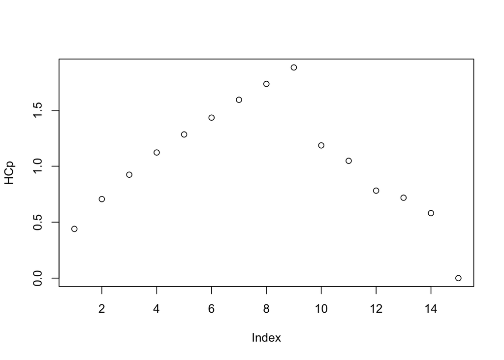

```r
pvalues<-c(0.0024,0.0056,0.0096,0.0121,0.0201,0.0278,0.0298,0.0344,0.0349,0.3240,0.4262,0.5719,0.6528,0.7590,1.000)

# IF-PCA

IF_PCA <- function (pvals){
  p<-length(pvals)
  HCp<-NULL
  for ( k in seq_along(pvals)){
    HCpk<-sqrt(p)*(k/p-pvals[k])/(sqrt(k/p+max(sqrt(k/p-pvals[k]),0)))
    HCp<-c(HCp, HCpk)
  }

  return (HCp)
}

HCp<-IF_PCA(pvalues)
plot(HCp)
```

可以看出根据IF-PCA方法同样在9处取得最大值，与例题得到的结果一致

# 4.5

**请对第一章的问题2里的Gordon研究，通过习题4.4编写的程序进行基因的有效性检验，绘制HC图，判断无效基因的数量**

```r
gene <- read.table("/Users/jiayaobo/PycharmProjects/nonparams/homework7/EX181.txt", header = T)
gene <- gene[, !names(gene) %in% c("ProbeSet")]
alpha<-0.05
pvals<-rep(0,12533)
for (i in  2:12533){
  d<-as.numeric(gene[i, ])
  pvals[i-1]<-ks.test(d[32:181],d[2:31])$p.value
}
```

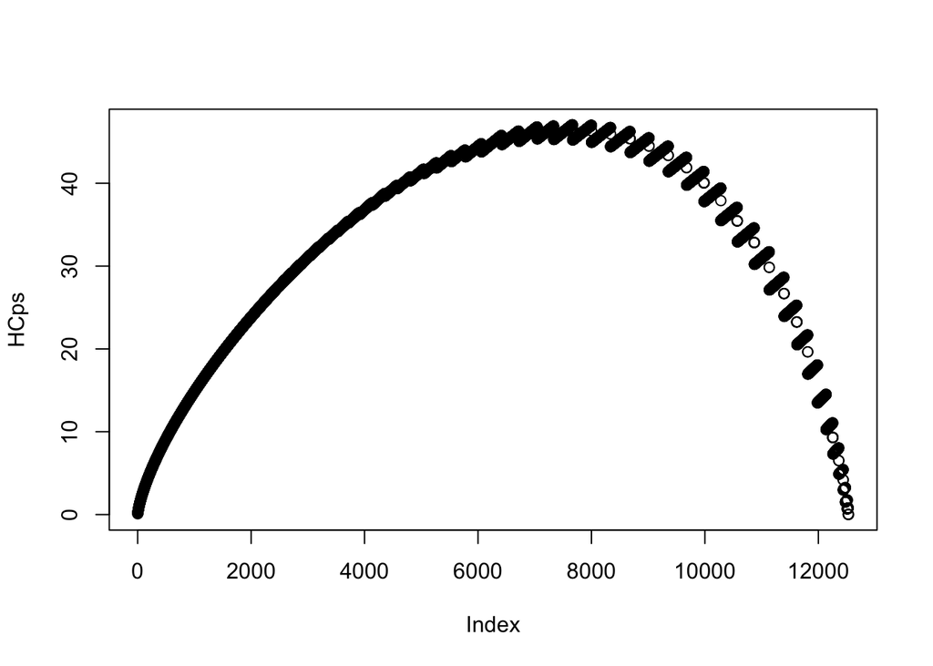

```r
pvals <- sort(pvals)
HCps<-IF_PCA(pvals = pvals)
plot(HCps)
```

根据HC图可以得知大概在7700处取得最大值，因而无效基因数量大概为4830左右

# 4.6

**下表是美国三大汽车公司的5种不同的车型某年产品的油耗，在R中编写函数完成Hodge-Lehmmann调整秩和检验。试分析不同公司产品的油耗是否存在差异，请将Freidman检验和Hodges-Lehmmann调整秩和检验的结果进行比较**

```r
A<-c(20.3,21.2,18.2,18.6,18.5)
B<-c(25.6,24.7,19.3,19.3,20.7)
C<-c(24.0,23.1,20.6,19.8,21.4)


HL.test <- function (x,y,z){
  b<-length(x)
  k<-3
  ao_x <- x - mean(x)
  ao_y <- y - mean(y)
  ao_z <- z- mean(z)

  xyz.rank <- rank(c(ao_x,ao_y,ao_z))
  x.rank<-xyz.rank[seq_along(x)]
  y.rank<-xyz.rank[(length(x)+1):(length(x)+length(y))]
  z.rank<-xyz.rank[-seq_along(z)]
  x.mean_rank <- mean(x.rank)
  y.mean_rank <- mean(y.rank)
  z.mean_rank <- mean(z.rank)

  Ri_mean<-NULL
  for ( i in seq_along(x)){
    Ri_mean<-c(Ri_mean,(x.rank[i]+y.rank[i]+z.rank[i])/3)
  }
  s <- 0
  for (i in length(x)){
    for (j in 1:k){
      s <- s+(x.rank[i]-Ri_mean[i])^2+(y.rank[i]-Ri_mean[i])^2+(z.rank[i]-Ri_mean[i])^2
    }
  }

  ss<-(x.mean_rank-(k*b+1)/2)^2+(y.mean_rank-(k*b+1)/2)^2+(z.mean_rank-(k*b+1)/2)^2
  c<-(k-1)*b^2/s
  Q<-c*ss
  return (Q)
}

Q<-HL.test(A,B,C)
pchisq(Q, 3-1,lower.tail = F)
```

```
## [1] 0.2200526
```

```r
treat.Car <- rep(c(1,2,3,4,5),3)
block.Car <- c(rep(1,5), rep(2,5), rep(3,5))
Car <- c(A,B,C)
friedman.test(Car, treat.Car,  block.Car)
```

```
##
##  Friedman rank sum test
##
## data:  Car, treat.Car and block.Car
## Friedman chi-squared = 10.102, df = 4, p-value = 0.03875
```

根据HL检验pvalue=0.220>0.05,根据friedman检验pvalue=0.03875<0.05,从而通过了HL检验而未通过Friedman检验

# 4.7

**在一项健康测试中有三中生活方式，他们的减肥效果如下表所示。人们想知道从这些数据中是否能得到他们减肥效果一样的结论，如果减肥效果不同，试根据以上数据选择方法检验哪种效果更好，哪种最差**

```r
library(clinfun)
A <- c(3.7,3.7,3.0,3.9,2.7)
B <- c(7.3,5.2,5.3,5.7,6.5)
C <- c(9.0,4.9,7.1,8.7)
n<-c(5,5,4)
ABC <- list(A,B,C)
group_label <- as.ordered(factor(rep(1:length(n),n)))
jonckheere.test(unlist(ABC), group_label, alternative="increasing")
```

```
##
##  Jonckheere-Terpstra test
##
## data:
## JT = 59, p-value = 0.0009567
## alternative hypothesis: increasing
```

根据JT检验，p值为0.0009<0.001，从而拒绝原假设，三种生活方式减肥效果不一样，第一种最差，第三种最好

# 4.8

**为考察三位推销员甲、乙、丙的推销能力，设计实验，让推销员向制定的12位客户推销商品，若客户对推销员的推销服务满意则给1分，否则给0分。试检验三位推销员的推销效果是否相同。请问该题目可以使用$\chi^2$检验进行分析吗？请讨论比较的结论**

```r
# 使用Cochran检验

salesman1 <- c(1,1,1,1,1,1,0,0,1,1,1,0)
salesman2 <- c(0,1,0,1,0,0,0,1,0,0,0,0)
salesman3 <- c(1,0,1,0,0,1,0,1,0,0,0,1)
salesman <- matrix(c(salesman1, salesman2, salesman3), nrow=10, ncol=3)
nidot.salesman <- apply(salesman,1,sum)
ndotj.salesman <- apply(salesman,2,sum)
k <- ncol(salesman)
Q <- (k-1)*(k*sum(ndotj.salesman^2)-(sum(ndotj.salesman))^2)/(k*sum(nidot.salesman)-sum(nidot.salesman^2))
pvalue.salesman <- pchisq(Q,k-1,lower.tail = F)
pvalue.salesman
```

```
## [1] 0.07243976
```

由于p=0.0724，从而使用Cochron检验，我们接受原假设，表明三种售货员的销售能力相同，但是明显看出第一名销售员的推销能力要强于另外两位，这表明给定显著性水平下，三位推销员共同放到一起进行检验，两位表现相近的销售员会抵消一位表现突出的推销员的表现，因而本情况不太适合用卡方检验

# 4.9

**现有A,B,C,D,4种驱蚊药剂，在南部4个地区试用，观察试验结果。受试验条件所限，每种药剂只在三个地区试验，每一试验试用400只蚊子，其死亡数据如下。如何检验4种药剂的药效是否不同**

```r
# Durbin 不完全区组分析法
t<-3
k<-4
r<-3
v<-4-1
x1 <- c(356,338,372)
x2 <- c(320, 340,308)
x3 <- c(359, 380, 332)
x4<- c(385, 390, 348)
ndotj <- c(6, 6, 9, 3)
Eri <- r*(t+1)/2

Q <- 12*(k-1)/(r*k*(t^2-1))*(sum((ndotj-Eri)^2))

pchisq(Q, k-1, lower.tail = F)
```

```
## [1] 0.08030773
```